# RSI Exercise

Rohan Agarwal

2022-10-14

```r
library (haven)
library (Hmisc)
library (stargazer)
```

```
##  Hlavac, Marek (2022). stargazer: Well-Formatted Regression and Summary Statistics Tables.
```

```
##  R package version 5.2.3. https://CRAN.R-project.org/package=stargazer
```

```r
library (tidyverse)
```

```r
library (dplyr)
library(ggplot2)
library (TSstudio)
library (zoo)
library(data.table)
setwd("~/Desktop/HFT/Trading indicators python/Trading-Indicators")
```

# In this R practice, I will use stock price data from the past 5 years to construct a Relative Stength Index.

**The RSI is a momentum indicator that is used in technical analysis to:**

- measure the speed and magnitude of a security’s recent price changes.
- evaluate undervalued and overvalued conditions in security price.

The RSI indicates securities primed for trend reversals and collective price pullbacks.

It signals to traders when to buy and when to sell.

- **RSI > 70:** the stock is overbought **(overvalued).**
- **RSI < 30:** the stock is oversold **(undervalued).**

It compares the strength of securities on days when prices go up to the strength on days when they go down.

$$RSI_{stepone}= 100 - [\frac{100}{1+\frac{avg. gain}{avg. loss}}]$$

$$RSI_{steptwo} = 100 - [\frac{100}{1 + \frac{(Pvt. Avg. Gain *
13)+current gain}
{(Pvt. Avg. Loss * 13) + current loss}}]$$
**Installing the libraries that will allow me to download the data.**

For this program, I will calculate the RSI for the following 6 tech stocks: - Meta

- Amazon
- Apple
- Netflix
- Google
- Microsoft

```r
library(quantmod)
library (broom)
library (magrittr)
```

Defining the start and end dates for the program and getting the stock price data required.

```r
start <- as.Date ("2017-10-14")
end <- as.Date ("2022-10-14")
getSymbols(c("META", "AMZN","AAPL","NFLX","GOOG","MSFT"), src = "yahoo", from = start, to = end)
```

```
## pausing 1 second between requests for more than 5 symbols
## pausing 1 second between requests for more than 5 symbols
```

```
## [1] "META" "AMZN" "AAPL" "NFLX" "GOOG" "MSFT"
```

## Reorganizing the data to keep only the adjusted closing share price

**Using an XTS object for the share price time series data.**

```r
stocks = as.xts(data.frame (Meta = META[,"META.Adjusted"],
                            Amazon = AMZN[, "AMZN.Adjusted"],
                            Apple = AAPL[, "AAPL.Adjusted"],
                            Netflix = NFLX[, "NFLX.Adjusted"],
                            Alphabet = GOOG[, "GOOG.Adjusted"],
                            Microsoft = MSFT[, "MSFT.Adjusted"])
                )
colnames(stocks) <- c("Meta", "Amazon", "Apple", "Netflix", "Alphabet", "Microsoft")
index(stocks) = as.Date(index(stocks))
```

**Plotting the stock prices of the 6 stocks of interest.**

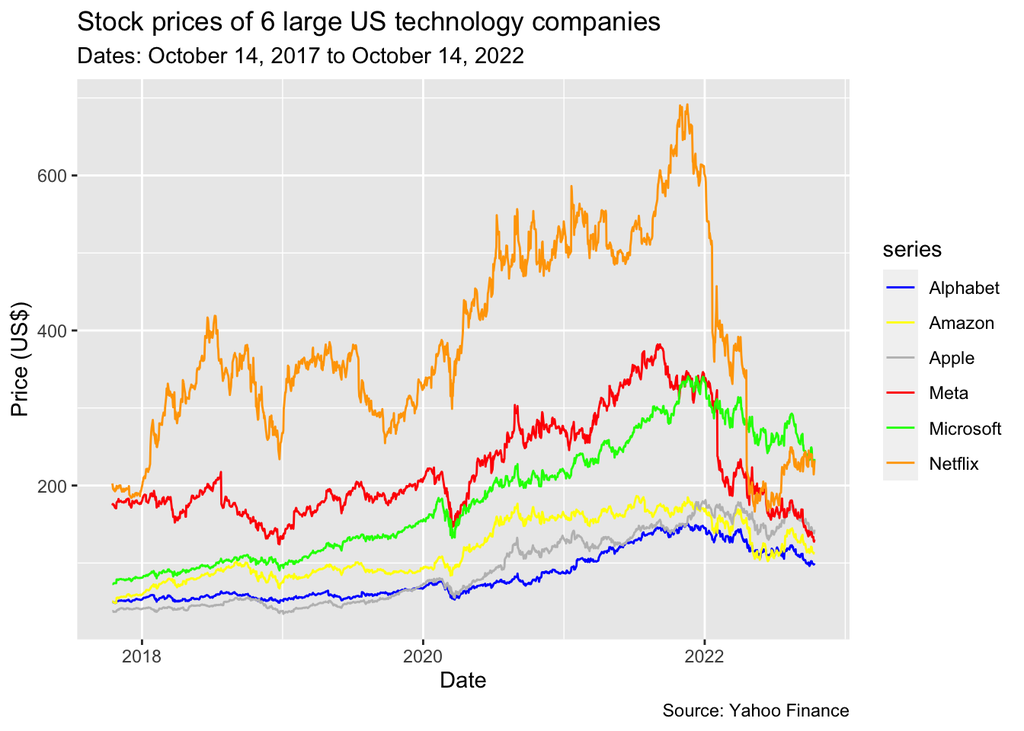

```r
stocks_series = tidy(stocks) %>%
  ggplot(aes(x= index, y = value, color = series))+
  labs(title = "Stock prices of 6 large US technology companies",
       subtitle = "Dates: October 14, 2017 to October 14, 2022",
       caption = "Source: Yahoo Finance")+
  xlab("Date") + ylab ("Price (US$)") +
  scale_color_manual(values = c("Blue", "Yellow", "Gray", "Red", "Green", "Orange")) +
  geom_line()

stocks_series
```

# Programming the RSI function.

- First, I will program RSI functions for each of the six stocks which I have.
- Step 1 : add columns containing the RSI for each of the six stocks next to their adjusted closing price.
- Step 2: Create diagrams with the stock price graph above and the RSI graph below for each of the six stocks chosen for this analysis.

```r
myRSI <- function (price,n){
  N <- length(price)
  U <- rep(0,N)
  D <- rep(0,N)
  rsi <- rep(NA,N)
  Lprice <- Lag(price,1)
  for (i in 2:N){
    if (price[i]>=Lprice[i]){
      U[i] <- 1
    } else {
      D[i] <- 1
    }
    if (i>n){
      AvgUp <- mean(U[(i-n+1):i])
      AvgDn <- mean(D[(i-n+1):i])
      rsi[i] <- AvgUp/(AvgUp+AvgDn)*100
      }
    }
  rsi <- reclass(rsi, price)
  return(rsi)
}


rsi_meta <- myRSI(stocks$Meta, n = 14)
rsi_amzn <-myRSI(stocks$Amazon, n =14)
rsi_aapl <- myRSI(stocks$Apple, n = 14)
rsi_nflx <- myRSI (stocks$Netflix, n = 14)
rsi_goog <- myRSI (stocks$Alphabet, n =14)
rsi_msft <- myRSI (stocks$Microsoft, n = 14)
```

**Adding the 6 RSI XTS objects to the stocks XTS object and dsiplaying descriptive statistics about the RSIs**

```r
stocks.f <- merge (stocks, rsi_meta, rsi_amzn, rsi_aapl, rsi_nflx, rsi_goog, rsi_msft)
colnames(stocks.f) <- c("Meta", "Amazon", "Apple", "Netflix", "Alphabet", "Microsoft", "Meta RSI", "Amazon RSI",
                        "Apple RSI", "Netflix RSI", "Alphabet RSI", "Microsoft RSI")
stocks.df <- as.data.frame(stocks.f)

stargazer (stocks.df, min.max = TRUE, mean.sd = TRUE, nobs = TRUE, median = TRUE,
           iqr = TRUE, align = TRUE,
           type = "text", title = "Descriptive Statistics about the mean stock price and RSI functions of the six technology companies",
           digits = 3)
```

```
##
## Descriptive Statistics about the mean stock price and RSI functions of the six technology companies
## ==============================================================================
## Statistic       N    Mean   St. Dev.   Min   Pctl(25) Median  Pctl(75)   Max
## ------------------------------------------------------------------------------
## Meta          1,258 220.634  63.856  124.060 175.285  194.595 266.938  382.180
## Amazon        1,258 118.155  37.513  48.315   87.753  107.216 158.094  186.570
## Apple         1,258 92.605   47.013  34.367   47.099  77.499  137.971  181.260
## Netflix       1,258 383.787 124.148  166.370 294.207  361.865 494.558  691.690
## Alphabet      1,258 84.133   31.937  48.423   57.219  70.670  113.341  150.709
## Microsoft     1,258 183.786  78.195  72.907  106.779  175.291 253.185  340.883
## Meta RSI      1,244 51.303   11.323  14.286   42.857  50.000   57.143  85.714
## Amazon RSI    1,244 53.784   12.938  21.429   42.857  57.143   64.286  85.714
## Apple RSI     1,244 53.330   12.924  21.429   42.857  50.000   64.286  85.714
## Netflix RSI   1,244 51.074   12.911  14.286   42.857  50.000   57.143  92.857
## Alphabet RSI  1,244 53.904   12.434  21.429   42.857  57.143   64.286  85.714
## Microsoft RSI 1,244 54.817   11.967   7.143   50.000  57.143   64.286  85.714
## ------------------------------------------------------------------------------
```

**Creating graphs using *ggplot2* with the stock price on top and the RSI on the bottom**

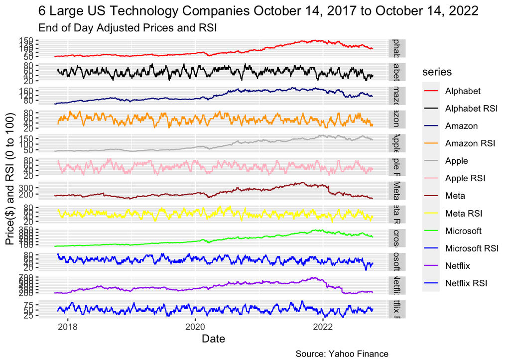

```r
stocks_series2 = tidy(stocks.f) %>%

  ggplot(aes(x=index,y=value, color=series)) +
  geom_line() +
  facet_grid(series~.,scales = "free") +
  labs(title = "6 Large US Technology Companies October 14, 2017 to October 14, 2022",

                                              subtitle = "End of Day Adjusted Prices and RSI",
                                              caption = " Source: Yahoo Finance") +

  xlab("Date") + ylab("Price($) and RSI (0 to 100)") +
  scale_color_manual(values = c("Red", "Black", "DarkBlue","Orange", "Grey", "Pink", "Brown", "Yellow", "Green", "Blue", "Purple", "Blue"))
stocks_series2
```